# Reproducible Research: Peer Assessment 1

## Are there differences in activity patterns between weekdays and weekends?

The textual writeup for this is after the R Code.

```r
# did calculations by day
activityLog.byDayC <- cbind(activityLog.byDayB, DayOfWeek = weekdays(as.Date(activityLog.byDayB$date)))

# the following function correctly determines whether Weekday or weekend
#if (weekdays(as.Date(activityLog.byDayC$date)) %in% c("Monday", "Tuesday", "Wednesday", #"Thursday", "Friday")) { "Weekday"} else {"Weekend"}

# filter for Weekday and get subset
activityLog.byDay.Weekday <- activityLog.byDayC %>%
  select(date, SumSteps, MeanSteps, DayOfWeek) %>%
  filter(DayOfWeek %in% c("Monday", "Tuesday", "Wednesday", "Thursday", "Friday"))

# filter for Weekend and get subset
activityLog.byDay.Weekend <- activityLog.byDayC %>%
  select(date, SumSteps, MeanSteps, DayOfWeek) %>%
  filter(!(DayOfWeek %in% c("Monday", "Tuesday", "Wednesday", "Thursday", "Friday")))


# add WeekdayOrWeekend to the respective datasets
activityLog.byDay.Weekday <- cbind(activityLog.byDay.Weekday, WeekdayOrWeekend = "Weekday")
activityLog.byDay.Weekend <- cbind(activityLog.byDay.Weekend, WeekdayOrWeekend = "Weekend")

# recreate dataset
activityLog.byDay.All <- rbind(activityLog.byDay.Weekday, activityLog.byDay.Weekend)


# add weekday vs weekend column
activityLog.byIntvC <- cbind(activityLog.byIntvB, DayOfWeek = weekdays(as.Date(activityLog.byIntvB$date)))

# filter for Weekday and get subset
activityLog.byIntvC.Weekday <- activityLog.byIntvC %>%
  select(date, interval, steps, DayOfWeek) %>%
  filter(DayOfWeek %in% c("Monday", "Tuesday", "Wednesday", "Thursday", "Friday"))

# filter for Weekend and get subset
activityLog.byIntvC.Weekend <- activityLog.byIntvC %>%
  select(date, interval, steps, DayOfWeek) %>%
  filter(!(DayOfWeek %in% c("Monday", "Tuesday", "Wednesday", "Thursday", "Friday")))

# add WeekdayOrWeekend to the respective datasets
activityLog.byIntvC.Weekday <- cbind(activityLog.byIntvC.Weekday, WeekdayOrWeekend = "Weekday")
activityLog.byIntvC.Weekend <- cbind(activityLog.byIntvC.Weekend, WeekdayOrWeekend = "Weekend")

# group by TimePeriod
activityLog.byIntvCSum.Weekend <- activityLog.byIntvC.Weekend %>%
  group_by(interval) %>%
  summarize(SumSteps = sum(steps, na.rm = TRUE), MeanSteps = mean(steps, na.rm = TRUE))


# group by TimePeriod
activityLog.byIntvCSum.Weekday <- activityLog.byIntvC.Weekday %>%
  group_by(interval) %>%
  summarize(SumSteps = sum(steps, na.rm = TRUE), MeanSteps = mean(steps, na.rm = TRUE))
```

To segrgate Weekdays and Weekends, I first added a DayOfWeek variable (using cbind) to the dataset using the weekday function on the date variable (after converting to Date). Next, I subset the datasets by weekdays and weekend days. I then added a variable (using cbind) to each subset for “Weekday” or “Weekend” in a new variable called WeekdayOrWeekend. I then combined th two subsets back together using rbind.

I did the analysis both “per day” (for comparison) and “per interval across days” (per the question). First, looking at “per day”, we get the following.

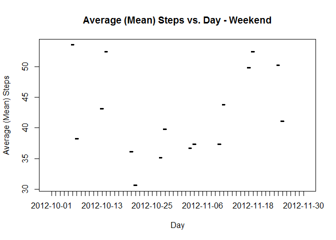

```r
# plot4 - here placed Row 1, Column 2
plot(
  x = activityLog.byDay.Weekend$date,
  y = activityLog.byDay.Weekend$MeanSteps,
  type = "l",
  main = "Average (Mean) Steps vs. Day - Weekend",
  xlab = "Day",
  ylab = "Average (Mean) Steps"
)
```

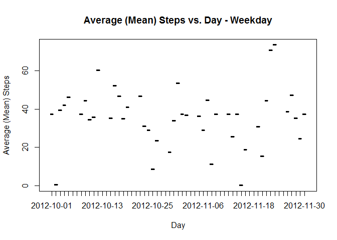

```r
# plot4 - here placed Row 1, Column 2
plot(
  x = activityLog.byDay.Weekday$date,
  y = activityLog.byDay.Weekday$MeanSteps,
  type = "l",
  main = "Average (Mean) Steps vs. Day - Weekday",
  xlab = "Day",
  ylab = "Average (Mean) Steps"
)
```

Next (per the question), looking at the “per interval across days”, we see the following.

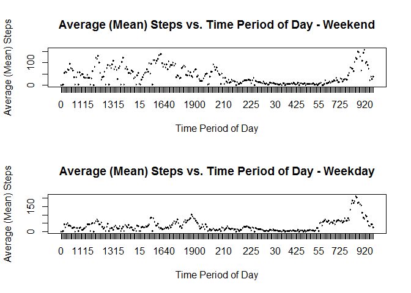

```r
par(mfrow = c(2,1))

# plot4 - here placed Row 1, Column 2
plot(
  x = activityLog.byIntvCSum.Weekend$interval,
  y = activityLog.byIntvCSum.Weekend$MeanSteps,
  type = "l",
  main = "Average (Mean) Steps vs. Time Period of Day - Weekend",
  xlab = "Time Period of Day",
  ylab = "Average (Mean) Steps"
)


# plot4 - here placed Row 1, Column 2
plot(
  x = activityLog.byIntvCSum.Weekday$interval,
  y = activityLog.byIntvCSum.Weekday$MeanSteps,
  type = "l",
  main = "Average (Mean) Steps vs. Time Period of Day - Weekday",
  xlab = "Time Period of Day",
  ylab = "Average (Mean) Steps"
)
```